# Stock Analysis of the ALL ORDs

# Abstract

The ALL ORDs (all ordinaries) is the top 500 shares of the ASX (Australian Stock Exchange). Shares in the ASX are grouped into the sectors that the companies operate in. This project is a stock analysis of the ALL ORDs index of the ASX which attempts to understand the role sector plays in the ASX as well as to identify top and bottom shares.

As this data is relatively clean the most important part of this project is the identification of which columns play the largest role and how they relate to each other.

Shares in general are a great way to save money and an easy way to diversify savings. This project will attempt to identify the shares that are best suited for different types of investment. Additionally, this project will drill down on sector in an attempt to understand how sector affects a shares performance.

# 1. Motivation

The share market is hard to predict as there are many factors that influence it, some completely unpredictable (including scandels). Many people attempt to understand and make prediction on the share market and thus this project will attempt to find understanding that others have not or at the very least further educate investment decisions.

An example of recent events that have affected major shares are the royal commission and the election. Specifically looking at NAB (National Australia Bank), the share price of it initially fell (after the royal commission) and then rose (after Liberal were elected). Between this period there was a decent profit to be made. NAB can also be looked at as a good passive share (or dividend/yield stock) and these movement would generally not affect people that bought it as such. NAB it is a company that pays a full franking (tax free), reasonably high dividend, thus a good place to invest (like with all the major banks on the ASX).

Another example that my project could not account for is the recent upturn, in the share market, of rare metal companies. Rare metals have been a very strong export (as Australia is one of the few places to export Cobolt as an example) and are expected to rise further as Trumps trade war continues, forcing foreign countries look to other places to obtain there metals. Recent events like this have given a boost to rare metal companies, however as my project is not a historical analysis it would not pick up on sudden trends like this and it is hard to find a database that can be used to account for current events.

This project however should be able to identify trends like NAB when it was lowest being a strong investment or at least further educate someone looking at buying a share.

# 2. The data

The first dataset used come from FactSet, FactSet Research Systems provides computer-based financial data and analysis. It consolidates data on global markets, public and private companies, and equity and fixed-income portfolios. (databases are not listed on factset website thus dataset is included with this project)

The second dataset used comes from Market Index, a financial portal for the Australian stock market. It provides up-to-date ASX market analysis, share prices, charts and index performance data in an easy-to-digest format and links to easy-to-use datasets. https://www.asx.com.au/asx/research/ASXListedCompanies.csv (the second dataset used)

# 3. Data preparation

Code and comments on how the raw data is put in a usable form (i.e., how you go from the raw data set(s) to the dataframe you are using for the analysis).

**Create as many code, markdown and raw cells as needed**

```python
from math import *
import numpy as np
import pandas as pd
from pathlib import Path
from IPython.display import display, HTML
import seaborn as sns
sns.set_style('white')

# colormap definitions
from matplotlib import cm

%matplotlib inline
import matplotlib.pyplot as plt

import string
import openpyxl
import xlrd
import csv
pd.set_option('display.max_columns', 500)
pd.set_option('display.width', 1000)
```

Just a note while EV is enterprise valuation and is done with respects to a companies EBIT or EBITDA, there is some insight to be gained from using both however it is minimal compared to using EBITDA so I will only refer to that.

```python
path1 = Path("../downloads/ALL_ORDS.xlsx")
df1 = pd.read_excel(path1, skiprows=4)
df1.dropna(thresh=2, inplace=True)
df1 = df1.reset_index(drop=True)
df1 = df1.drop(0)
df1 = df1.dropna(how='all', axis=1)
df1 = df1.reset_index(drop=True)
df1['ASX Code']=df1['ASX Code'].apply(lambda x: ((str(x)).split('-'))[0])
df1.rename(columns={'ASX Code': 'Code'}, inplace=True)
del df1['Current Ratio']
df1.fillna(0)
df1.head()
```

|  | Symbol | Name | Code | Earns Per Share | FE Eps Mean FY1 Roll | Divs | FE Dps Mean FY1 Roll | FE Val Div_Yld Mean FY1 | FE Mkt_Cap | Total Debt% Equity | Closing Price | Price / Earns Ratio | FE Val Pe Mean FY1 | FE Val Ev_Ebit Mean FY1 | FE Val Ev_Ebitda Mean FY1 | Local Price 52 Week High | Local Price 52 Week Low | Total CVol |
| --- | --- | --- | --- | --- | --- | --- | --- | --- | --- | --- | --- | --- | --- | --- | --- | --- | --- | --- |
| 0 | 608820 | Beach Energy Limited | BPT | 0.0916 | 0.222570 | 0.02 | 0.022885 | 1.094958 | 4898.2350 | 50.36453 | 2.0900 | 19.15939 | 9.390306 | 5.952856 | 3.560849 | 2.260 | 1.275 | 3.155694 |
| 1 | BB7MQZ | Byron Energy Limited | BYE | 0.0028 | 0.025000 | NaN | NaN | NaN | 205.1351 | 22.75775 | 0.3000 | 126.78540 | 12.000000 | 8.425116 | 6.820332 | 0.412 | 0.195 | 0.366123 |
| 2 | 616150 | Caltex Australia Limited | CTX | 2.1472 | 1.955642 | 1.18 | 1.143820 | 4.252908 | 7133.1670 | 28.47551 | 26.8950 | 11.86662 | 13.752520 | 10.671920 | 7.554939 | 33.650 | 24.500 | 1.962764 |
| 3 | 611049 | Carnarvon Petroleum Limited | CVN | 0.0014 | -0.004033 | NaN | 0.000000 | 0.000000 | 577.3722 | 0.00000 | 0.4375 | 107.14290 | NaN | NaN | NaN | 0.695 | 0.130 | 1.651001 |
| 4 | B00G14 | Comet Ridge Ltd | COI | -0.0034 | -0.007000 | NaN | 0.000000 | 0.000000 | 218.3629 | 0.00000 | 0.2950 | NaN | NaN | NaN | NaN | 0.420 | 0.260 | 0.195973 |

```python
path2 = Path("../downloads/20190301-asx-listed-companies.csv")
df2 = pd.read_csv(path2, skiprows=1)
df2 = df2.dropna(how='all', axis=1)
df2['Market Cap'] = df2['Market Cap'].replace(',', '', regex=True).astype(str)
df2.head()
```

|  | Code | Company | Sector | Market Cap | Weight(%) | Total Index Market Cap | Unnamed: 7 |
| --- | --- | --- | --- | --- | --- | --- | --- |
| 0 | 14D | 1414 Degrees Limited | Industrials | 48249300 | 0.002 | 2,085,162,417,120 | NaN |
| 1 | 1ST | 1ST Group Limited | Health Care | 7843610 | 0.000 | NaN | NaN |
| 2 | 3PL | 3P Learning Limited | Consumer Discretionary | 152571000 | 0.007 | Sector Breakdown | NaN |
| 3 | 4DS | 4DS Memory Limited | Information Technology | 80947600 | 0.004 | Consumer Discretionary | 1.92 |
| 4 | 5GN | 5G Networks Limited | Telecommunication Services | 23498500 | 0.001 | Consumer Staples | 1.84 |

```python
df = pd.merge(df1 , df2[['Sector','Market Cap', 'Weight(%)','Code']],on='Code')
del df['Symbol']
del df['Name']
df['Sector'] = df['Sector'].astype('category')
```

```python
#Had to do it this way as there was an issue doing multiple columns

#One of them had wrong formating ',' seperating numbers sorted it out
#earlier and decided to just keep these as they are
#FE is Forward estimate
df['Earns Per Share'] = pd.to_numeric(df['Earns Per Share'])
df['FE Eps Mean FY1 Roll'] = pd.to_numeric(df['FE Eps Mean FY1 Roll']) #EPS is earns per share
df['FE Dps Mean FY1 Roll'] = pd.to_numeric(df['FE Dps Mean FY1 Roll']) #DPS is dividends per share
df['FE Val Div_Yld Mean FY1'] = pd.to_numeric(df['FE Val Div_Yld Mean FY1'] )
df['Divs'] = pd.to_numeric(df['Divs'] )
df['FE Mkt_Cap'] = pd.to_numeric(df['FE Mkt_Cap'] )
df.iloc[:,7] =  pd.to_numeric(df.iloc[:,7] )
df['Market Cap'] = pd.to_numeric(df['Market Cap'])

df['Closing Price'] = pd.to_numeric(df['Closing Price'] )
df['Price / Earns Ratio'] =pd.to_numeric(df['Price / Earns Ratio'])
df['FE Val Pe Mean FY1'] = pd.to_numeric(df['FE Val Pe Mean FY1'] ) #PE is Price/Earns
df['FE Val Ev_Ebit Mean FY1'] = pd.to_numeric(df['FE Val Ev_Ebit Mean FY1'] )
df['FE Val Ev_Ebitda Mean FY1'] = pd.to_numeric(df['FE Val Ev_Ebitda Mean FY1'])
df['Local Price 52 Week High'] = pd.to_numeric(df['Local Price 52 Week High'])
df['Local Price 52 Week Low'] = pd.to_numeric(df['Local Price 52 Week Low'])
df['Total CVol'] = pd.to_numeric(df['Total CVol'])

df['Market Cap'] = pd.to_numeric(df['Market Cap'])
df.iloc[:,-1] =  pd.to_numeric(df.iloc[:,-1] )
df['Market Cap']=df['Market Cap'].astype('float64')
df.dtypes
```

```
Code                           object
Earns Per Share               float64
FE Eps Mean FY1 Roll          float64
Divs                          float64
FE Dps Mean FY1 Roll          float64
FE Val Div_Yld Mean FY1       float64
FE Mkt_Cap                    float64
Total Debt% Equity            float64
Closing Price                 float64
Price / Earns Ratio           float64
FE Val Pe Mean FY1            float64
FE Val Ev_Ebit Mean FY1       float64
FE Val Ev_Ebitda Mean FY1     float64
Local Price 52 Week High      float64
Local Price 52 Week Low       float64
Total CVol                    float64
Sector                       category
Market Cap                    float64
Weight(%)                     float64
dtype: object
```

```python
df['52 Week High/Low difference'] = df['Local Price 52 Week High']-df['Local Price 52 Week Low']
df.iloc[:,0:-5]=df.iloc[:,0:-5].fillna(0)
df.iloc[:,-1:-3]=df.iloc[:,-1:-3].fillna(0)
df['FE Mkt_Cap']=df['FE Mkt_Cap']*1000000
df['52 Week High/Low difference(%)'] = ((df['Local Price 52 Week High']-
df['Local Price 52 Week Low'])*100)/df['Local Price 52 Week Low']
```

EV is best looked at as a factor of a companies performance compared to sector. If a company has an EV at 4 times the sector EV it is either performing exceptionally well or is overvalued, likewise if it is below the sector EV it is either performing badly or undervalued. Thus, looking for low EV ones and a knowledge of the company is necessary to determine where it lies.

```python
Extra= (df[(df['FE Val Ev_Ebitda Mean FY1']>0.1)&(df['FE Val Ev_Ebitda Mean FY1']<200)].groupby('Sector', as_index=False)
       .agg({'FE Val Ev_Ebitda Mean FY1':'mean'})
       .rename(columns={'FE Val Ev_Ebitda Mean FY1':'EV Sector'}))
df = pd.merge(df , Extra ,on='Sector')
pd.options.display.float_format = '{:.2f}'.format
df['Eps growth'] = df['FE Eps Mean FY1 Roll']-df['Earns Per Share']
df['Dps growth'] = df['FE Dps Mean FY1 Roll']-df['Divs']
df['Dividend yld']=(df['Divs']/df['Closing Price'])*100
df['Dps yld growth'] = df['FE Val Div_Yld Mean FY1']-df['Dividend yld']
df.head()
```

|  | Code | Earns Per Share | FE Eps Mean FY1 Roll | Divs | FE Dps Mean FY1 Roll | FE Val Div_Yld Mean FY1 | FE Mkt_Cap | Total Debt% Equity | Closing Price | Price / Earns Ratio | FE Val Pe Mean FY1 | FE Val Ev_Ebit Mean FY1 | FE Val Ev_Ebitda Mean FY1 | Local Price 52 Week High | Local Price 52 Week Low | Total CVol | Sector | Market Cap | Weight(%) | 52 Week High/Low difference | 52 Week High/Low difference(%) | EV Sector | Eps growth | Dps growth | Dividend yld | Dps yld growth |
| --- | --- | --- | --- | --- | --- | --- | --- | --- | --- | --- | --- | --- | --- | --- | --- | --- | --- | --- | --- | --- | --- | --- | --- | --- | --- | --- |
| 0 | BPT | 0.09 | 0.22 | 0.02 | 0.02 | 1.09 | 4898235000.00 | 50.36 | 2.09 | 19.16 | 9.39 | 5.95 | 3.56 | 2.26 | 1.27 | 3.16 | Energy | 4738760000.00 | 0.23 | 0.98 | 77.25 | 7.61 | 0.13 | 0.00 | 0.96 | 0.14 |
| 1 | BYE | 0.00 | 0.03 | 0.00 | 0.00 | 0.00 | 205135100.00 | 22.76 | 0.30 | 126.79 | 12.00 | 8.43 | 6.82 | 0.41 | 0.20 | 0.37 | Energy | 232950000.00 | 0.01 | 0.22 | 111.28 | 7.61 | 0.02 | 0.00 | 0.00 | 0.00 |
| 2 | CTX | 2.15 | 1.96 | 1.18 | 1.14 | 4.25 | 7133167000.00 | 28.48 | 26.89 | 11.87 | 13.75 | 10.67 | 7.55 | 33.65 | 24.50 | 1.96 | Energy | 7459180000.00 | 0.36 | 9.15 | 37.35 | 7.61 | -0.19 | -0.04 | 4.39 | -0.13 |
| 3 | CVN | 0.00 | -0.00 | 0.00 | 0.00 | 0.00 | 577372200.00 | 0.00 | 0.44 | 107.14 | 0.00 | 0.00 | 0.00 | 0.69 | 0.13 | 1.65 | Energy | 543804000.00 | 0.03 | 0.56 | 434.62 | 7.61 | -0.01 | 0.00 | 0.00 | 0.00 |
| 4 | COI | -0.00 | -0.01 | 0.00 | 0.00 | 0.00 | 218362900.00 | 0.00 | 0.29 | 0.00 | 0.00 | 0.00 | 0.00 | 0.42 | 0.26 | 0.20 | Energy | 247478000.00 | 0.01 | 0.16 | 61.54 | 7.61 | -0.00 | 0.00 | 0.00 | 0.00 |

*Just a note that Dividend yld that I made is not very accurate as Divs is past dividend while closing price was the current one so it is a bit skewed, still useful for analysis though*

# 4. Exploratory data analysis

This is the main part of the project. Include code, plots, and detailed explanation of your analysis of the data. Be sure to include enough detail so that anyone can follow and understand what you are doing.

**Create as many code, markdown and raw cells as needed**

```python
df.corr().style.background_gradient(cmap='BuPu')
```

|  | Earns Per Share | FE Eps Mean FY1 Roll | Divs | FE Dps Mean FY1 Roll | FE Val Div_Yld Mean FY1 | FE Mkt_Cap | Total Debt% Equity | Closing Price | Price / Earns Ratio | FE Val Pe Mean FY1 | FE Val Ev_Ebit Mean FY1 | FE Val Ev_Ebitda Mean FY1 | Local Price 52 Week High | Local Price 52 Week Low | Total CVol | Market Cap | Weight(%) | 52 Week High/Low difference | 52 Week High/Low difference(%) | EV Sector | Eps growth | Dps growth | Dividend yld | Dps yld growth |
| --- | --- | --- | --- | --- | --- | --- | --- | --- | --- | --- | --- | --- | --- | --- | --- | --- | --- | --- | --- | --- | --- | --- | --- | --- |
| Earns Per Share | 1 | 0.941858 | 0.899853 | 0.874077 | 0.181851 | 0.616196 | 0.0134541 | 0.794232 | -0.038765 | -0.0241311 | -0.0466665 | -0.0375514 | 0.767685 | 0.786873 | -0.000578286 | 0.544881 | 0.544886 | 0.667258 | -0.186914 | 0.00161455 | -0.268464 | 0.263407 | 0.150935 | 0.0247215 |
| FE Eps Mean FY1 Roll | 0.941858 | 1 | 0.938871 | 0.942151 | 0.189785 | 0.66611 | 0.0130467 | 0.872546 | -0.027284 | -0.0237687 | -0.0434275 | -0.0416151 | 0.841781 | 0.867426 | -0.00375558 | 0.61865 | 0.618658 | 0.722673 | -0.191997 | -0.000327085 | 0.0708216 | 0.395528 | 0.110685 | 0.0820352 |
| Divs | 0.899853 | 0.938871 | 1 | 0.970982 | 0.228457 | 0.64871 | 0.0388025 | 0.817153 | -0.0294198 | -0.0247805 | -0.0436329 | -0.0421296 | 0.798762 | 0.82362 | -0.00290836 | 0.647694 | 0.647699 | 0.684719 | -0.1998 | 0.0130969 | 0.0202721 | 0.291228 | 0.209863 | 0.00674793 |
| FE Dps Mean FY1 Roll | 0.874077 | 0.942151 | 0.970982 | 1 | 0.265215 | 0.698879 | 0.0348764 | 0.815382 | -0.0294089 | -0.0199262 | -0.0383052 | -0.037558 | 0.793203 | 0.818494 | 0.00818031 | 0.671572 | 0.671588 | 0.67877 | -0.194694 | 0.00952446 | 0.106193 | 0.511562 | 0.155858 | 0.113222 |
| FE Val Div_Yld Mean FY1 | 0.181851 | 0.189785 | 0.228457 | 0.265215 | 1 | 0.179689 | 0.0650908 | 0.0449395 | -0.0646865 | -0.104173 | -0.104504 | -0.0998006 | 0.0441377 | 0.0642755 | 0.0691963 | 0.1918 | 0.191817 | 0.00121544 | -0.341454 | -0.0175285 | 0.00423657 | 0.240091 | 0.634026 | 0.371241 |
| FE Mkt_Cap | 0.616196 | 0.66611 | 0.64871 | 0.698879 | 0.179689 | 1 | 0.0578637 | 0.519323 | -0.0160804 | -0.00961736 | -0.00152482 | -0.0231771 | 0.46573 | 0.506141 | 0.191863 | 0.918799 | 0.91881 | 0.348654 | -0.145321 | -0.0283202 | 0.0803791 | 0.464911 | 0.0967078 | 0.0873843 |
| Total Debt% Equity | 0.0134541 | 0.0130467 | 0.0388025 | 0.0348764 | 0.0650908 | 0.0578637 | 1 | 0.0101193 | -0.00655403 | 0.000281075 | -0.00569175 | -0.00855275 | 0.00409344 | 0.0136861 | 0.016357 | 0.0764312 | 0.0764073 | -0.0149636 | -0.0517191 | 0.0324361 | -0.00253737 | 9.9405e-05 | 0.0602942 | 0.00132063 |
| Closing Price | 0.794232 | 0.872546 | 0.817153 | 0.815382 | 0.0449395 | 0.519323 | 0.0101193 | 1 | -0.000506205 | 0.0238157 | 0.121359 | -0.0103537 | 0.982073 | 0.990549 | -0.0471375 | 0.526679 | 0.526679 | 0.884962 | -0.149488 | 0.108801 | 0.143677 | 0.325746 | 0.00136929 | 0.0492513 |
| Price / Earns Ratio | -0.038765 | -0.027284 | -0.0294198 | -0.0294089 | -0.0646865 | -0.0160804 | -0.00655403 | -0.000506205 | 1 | 0.255229 | 0.147574 | 0.0168897 | 0.00365233 | -0.00386842 | 0.00739974 | -0.0168582 | -0.0168455 | 0.0180303 | 0.000134283 | 0.0597024 | 0.0368598 | -0.0119389 | -0.0662607 | 0.0063015 |
| FE Val Pe Mean FY1 | -0.0241311 | -0.0237687 | -0.0247805 | -0.0199262 | -0.104173 | -0.00961736 | 0.000281075 | 0.0238157 | 0.255229 | 1 | 0.410089 | 0.0708662 | 0.0191604 | 0.0117745 | -0.0143892 | -0.00869738 | -0.00871043 | 0.0320031 | -0.0359879 | 0.0938602 | 0.00349501 | 0.0093251 | -0.118397 | 0.0241838 |
| FE Val Ev_Ebit Mean FY1 | -0.0466665 | -0.0434275 | -0.0436329 | -0.0383052 | -0.104504 | -0.00152482 | -0.00569175 | 0.121359 | 0.147574 | 0.410089 | 1 | 0.165921 | 0.10067 | 0.0759466 | -0.0172598 | -0.00198492 | -0.0019851 | 0.140661 | 0.029551 | 0.198449 | 0.0140356 | 0.00354029 | -0.112789 | 0.017075 |
| FE Val Ev_Ebitda Mean FY1 | -0.0375514 | -0.0416151 | -0.0421296 | -0.037558 | -0.0998006 | -0.0231771 | -0.00855275 | -0.0103537 | 0.0168897 | 0.0708662 | 0.165921 | 1 | -0.0130072 | -0.0195093 | -0.00839726 | -0.0262066 | -0.0262313 | 0.000749596 | 0.0532636 | 0.0440373 | -0.00782808 | 0.00112747 | -0.106899 | 0.015329 |
| Local Price 52 Week High | 0.767685 | 0.841781 | 0.798762 | 0.793203 | 0.0441377 | 0.46573 | 0.00409344 | 0.982073 | 0.00365233 | 0.0191604 | 0.10067 | -0.0130072 | 1 | 0.985952 | -0.0508268 | 0.483488 | 0.483478 | 0.945377 | -0.132669 | 0.0892842 | 0.134285 | 0.3031 | 0.00767485 | 0.040772 |
| Local Price 52 Week Low | 0.786873 | 0.867426 | 0.82362 | 0.818494 | 0.0642755 | 0.506141 | 0.0136861 | 0.990549 | -0.00386842 | 0.0117745 | 0.0759466 | -0.0195093 | 0.985952 | 1 | -0.0437159 | 0.532593 | 0.532591 | 0.877648 | -0.171849 | 0.0896126 | 0.150843 | 0.314958 | 0.0225137 | 0.0457613 |
| Total CVol | -0.000578286 | -0.00375558 | -0.00290836 | 0.00818031 | 0.0691963 | 0.191863 | 0.016357 | -0.0471375 | 0.00739974 | -0.0143892 | -0.0172598 | -0.00839726 | -0.0508268 | -0.0437159 | 1 | 0.226608 | 0.226607 | -0.0605349 | 0.0553664 | -0.121118 | -0.00904992 | 0.0431724 | 0.0574472 | 0.00938873 |
| Market Cap | 0.544881 | 0.61865 | 0.647694 | 0.671572 | 0.1918 | 0.918799 | 0.0764312 | 0.526679 | -0.0168582 | -0.00869738 | -0.00198492 | -0.0262066 | 0.483488 | 0.532593 | 0.226608 | 1 | 1 | 0.347991 | -0.16723 | -0.00668568 | 0.156027 | 0.359325 | 0.116267 | 0.0776153 |
| Weight(%) | 0.544886 | 0.618658 | 0.647699 | 0.671588 | 0.191817 | 0.91881 | 0.0764073 | 0.526679 | -0.0168455 | -0.00871043 | -0.0019851 | -0.0262313 | 0.483478 | 0.532591 | 0.226607 | 1 | 1 | 0.347965 | -0.167232 | -0.00670419 | 0.156033 | 0.359371 | 0.116269 | 0.0776317 |
| 52 Week High/Low difference | 0.667258 | 0.722673 | 0.684719 | 0.67877 | 0.00121544 | 0.348654 | -0.0149636 | 0.884962 | 0.0180303 | 0.0320031 | 0.140661 | 0.000749596 | 0.945377 | 0.877648 | -0.0605349 | 0.347991 | 0.347965 | 1 | -0.045321 | 0.0813186 | 0.0909537 | 0.255091 | -0.0219145 | 0.0276898 |
| 52 Week High/Low difference(%) | -0.186914 | -0.191997 | -0.1998 | -0.194694 | -0.341454 | -0.145321 | -0.0517191 | -0.149488 | 0.000134283 | -0.0359879 | 0.029551 | 0.0532636 | -0.132669 | -0.171849 | 0.0553664 | -0.16723 | -0.167232 | -0.045321 | 1 | -0.0446215 | 0.00445185 | -0.0609545 | -0.240787 | -0.0975892 |
| EV Sector | 0.00161455 | -0.000327085 | 0.0130969 | 0.00952446 | -0.0175285 | -0.0283202 | 0.0324361 | 0.108801 | 0.0597024 | 0.0938602 | 0.198449 | 0.0440373 | 0.0892842 | 0.0896126 | -0.121118 | -0.00668568 | -0.00670419 | 0.0813186 | -0.0446215 | 1 | -0.00573068 | -0.00895609 | 0.0248854 | -0.0497322 |
| Eps growth | -0.268464 | 0.0708216 | 0.0202721 | 0.106193 | 0.00423657 | 0.0803791 | -0.00253737 | 0.143677 | 0.0368598 | 0.00349501 | 0.0140356 | -0.00782808 | 0.134285 | 0.150843 | -0.00904992 | 0.156027 | 0.156033 | 0.0909537 | 0.00445185 | -0.00573068 | 1 | 0.351959 | -0.13075 | 0.161793 |
| Dps growth | 0.263407 | 0.395528 | 0.291228 | 0.511562 | 0.240091 | 0.464911 | 9.9405e-05 | 0.325746 | -0.0119389 | 0.0093251 | 0.00354029 | 0.00112747 | 0.3031 | 0.314958 | 0.0431724 | 0.359325 | 0.359371 | 0.255091 | -0.0609545 | -0.00895609 | 0.351959 | 1 | -0.130553 | 0.428669 |
| Dividend yld | 0.150935 | 0.110685 | 0.209863 | 0.155858 | 0.634026 | 0.0967078 | 0.0602942 | 0.00136929 | -0.0662607 | -0.118397 | -0.112789 | -0.106899 | 0.00767485 | 0.0225137 | 0.0574472 | 0.116267 | 0.116269 | -0.0219145 | -0.240787 | 0.0248854 | -0.13075 | -0.130553 | 1 | -0.482672 |
| Dps yld growth | 0.0247215 | 0.0820352 | 0.00674793 | 0.113222 | 0.371241 | 0.0873843 | 0.00132063 | 0.0492513 | 0.0063015 | 0.0241838 | 0.017075 | 0.015329 | 0.040772 | 0.0457613 | 0.00938873 | 0.0776153 | 0.0776317 | 0.0276898 | -0.0975892 | -0.0497322 | 0.161793 | 0.428669 | -0.482672 | 1 |

Correlation table to show some of the relationships between the data, an interestng observation that makes sense is that the forward estimate for the EPS and DPS are highly correlated

Firstly lets look at Sector/Industry trends before drilling down on specific shares

```python
Sectors=df.groupby(['Sector'])
```

```python
Sectors['Closing Price'].agg([('Mean' , lambda x : x.mean()) ,
                              ('Median' , lambda x : x.median()) ,
                              ('Standard deviation' , lambda x : x.std()) ,
                              ('Variance' , lambda x : x.var()) ,

]),
```

```
(                            Mean  Median  Standard deviation  Variance
 Sector
 Consumer Discretionary      7.21    3.14                9.50     90.25
 Consumer Staples            8.75    4.72               16.87    284.76
 Energy                      4.84    0.58                8.90     79.13
 Financials                 11.80    3.68               22.14    490.18
 Health Care                16.48    1.94               44.05   1940.69
 Industrials                 5.42    2.41                7.96     63.33
 Information Technology      9.42    3.28               15.36    235.78
 Materials                   4.92    1.30               12.14    147.29
 Real Estate                 3.64    2.79                3.12      9.70
 Telecommunication Services  4.94    3.64                6.04     36.51
 Utilities                   4.44    1.78                7.17     51.42,)
```

```
'Number of shares in each Sector'
```

```
Sector
Consumer Discretionary        74
Consumer Staples              26
Energy                        30
Financials                    58
Health Care                   36
Industrials                   52
Information Technology        40
Materials                     90
Real Estate                   44
Telecommunication Services     9
Utilities                      9
dtype: int64
```

```
'Share Price information in Sectors'
```

| Sector | Mean | Median | Standard deviation | Variance |
| --- | --- | --- | --- | --- |
| Consumer Discretionary | 7.21 | 3.14 | 9.50 | 90.25 |
| Consumer Staples | 8.75 | 4.72 | 16.87 | 284.76 |
| Energy | 4.84 | 0.58 | 8.90 | 79.13 |
| Financials | 11.80 | 3.68 | 22.14 | 490.18 |
| Health Care | 16.48 | 1.94 | 44.05 | 1940.69 |
| Industrials | 5.42 | 2.41 | 7.96 | 63.33 |
| Information Technology | 9.42 | 3.28 | 15.36 | 235.78 |
| Materials | 4.92 | 1.30 | 12.14 | 147.29 |
| Real Estate | 3.64 | 2.79 | 3.12 | 9.70 |
| Telecommunication Services | 4.94 | 3.64 | 6.04 | 36.51 |
| Utilities | 4.44 | 1.78 | 7.17 | 51.42 |

```
'Weighted percentage of each Sector'
```

```
Sector
Consumer Discretionary        6.71
Consumer Staples              4.23
Energy                        5.93
Financials                   26.33
Health Care                   6.95
Industrials                   7.84
Information Technology        3.33
Materials                    16.36
Real Estate                   6.52
Telecommunication Services    2.38
Utilities                     1.81
Name: Weight(%), dtype: float64
```

```
'Average 52 Week High/Low percentage change'
```

```
Sector
Consumer Discretionary        93.31
Consumer Staples              95.26
Energy                       146.05
Financials                    75.36
Health Care                  147.36
Industrials                   88.35
Information Technology       105.38
Materials                    119.73
Real Estate                   36.67
Telecommunication Services   119.77
Utilities                     56.20
Name: 52 Week High/Low difference(%), dtype: float64
```

```
'Number of regressing/growing companies by EPS'
```

| Sector | negative | positive |
| --- | --- | --- |
| Consumer Discretionary | -14.00 | 60.00 |
| Consumer Staples | -10.00 | 16.00 |
| Energy | -10.00 | 20.00 |
| Financials | -29.00 | 29.00 |
| Health Care | -11.00 | 25.00 |
| Industrials | -16.00 | 36.00 |
| Information Technology | -12.00 | 28.00 |
| Materials | -33.00 | 57.00 |
| Real Estate | -38.00 | 6.00 |
| Telecommunication Services | -5.00 | 4.00 |
| Utilities | -4.00 | 5.00 |

```
'Mean regression/growth of companies by EPS'
```

| Sector | negative | positive |
| --- | --- | --- |
| Consumer Discretionary | -0.06 | 0.18 |
| Consumer Staples | -0.10 | 0.18 |
| Energy | -0.19 | 0.21 |
| Financials | -0.13 | 0.16 |
| Health Care | -0.04 | 0.14 |
| Industrials | -0.12 | 0.10 |
| Information Technology | -0.06 | 0.13 |
| Materials | -0.20 | 0.15 |
| Real Estate | -0.17 | 0.08 |
| Telecommunication Services | -0.06 | 0.11 |
| Utilities | -0.25 | 0.13 |

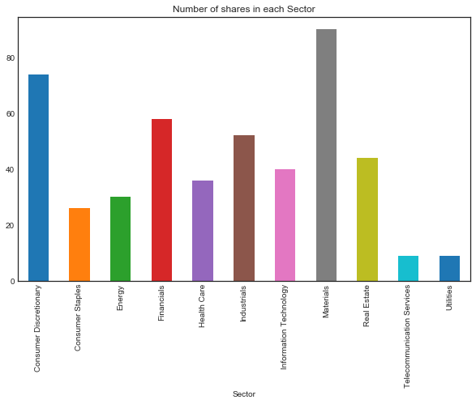

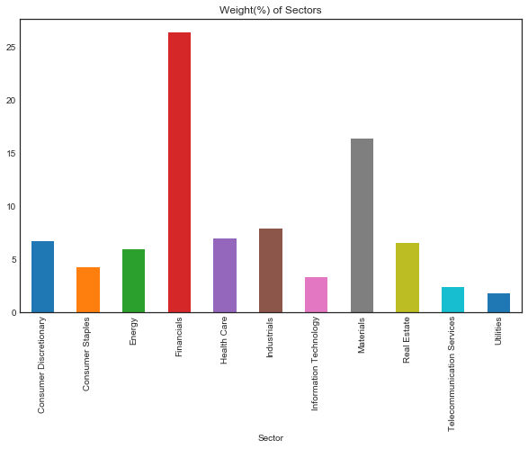

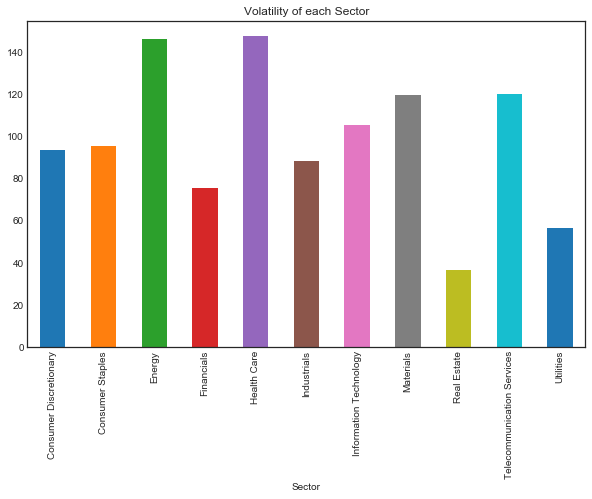

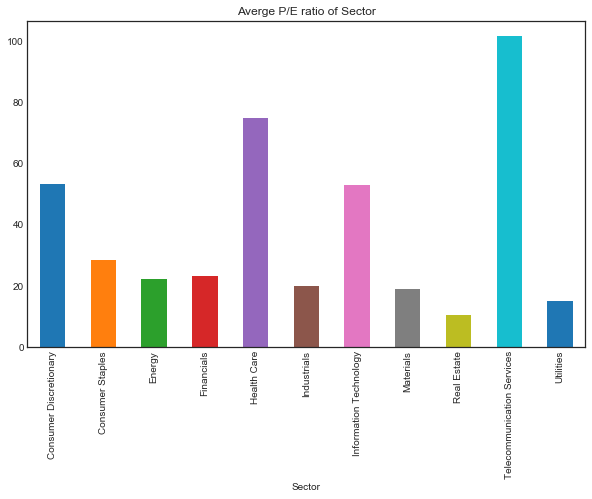

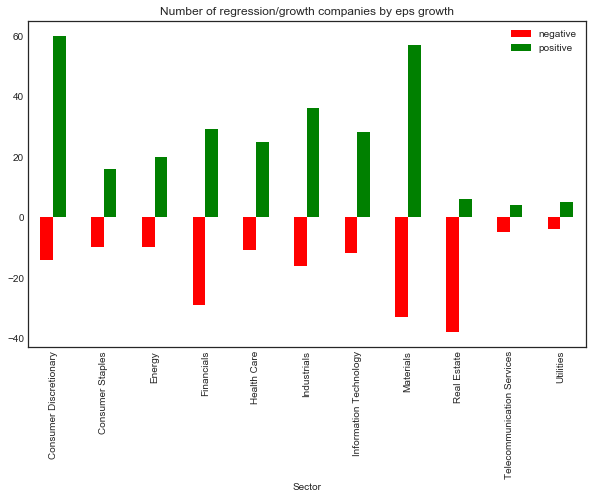

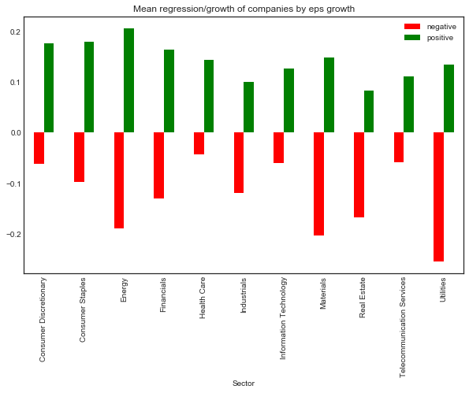

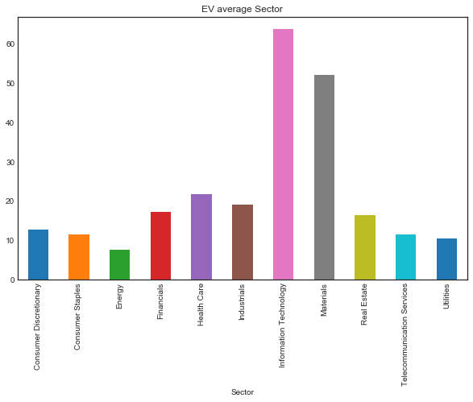

```python
display('Number of shares in each Sector',Sectors.size(),

'Share Price information in Sectors',
Sectors['Closing Price'].agg([('Mean' , lambda x : x.mean()) ,
                              ('Median' , lambda x : x.median()) ,
                              ('Standard deviation' , lambda x : x.std()) ,
                              ('Variance' , lambda x : x.var()) ,

]),

'Weighted percentage of each Sector',Sectors['Weight(%)'].sum(),

'Average 52 Week High/Low percentage change',Sectors['52 Week High/Low difference(%)'].mean(),

'Number of regressing/growing companies by EPS',Sectors['Eps growth'].agg([('negative' , lambda x : -x[x < 0].count()) ,
('positive' , lambda x : x[x > 0].count())]),

'Mean regression/growth of companies by EPS',Sectors['Eps growth'].agg([('negative' , lambda x : x[x < 0].mean()) ,
('positive' , lambda x : x[x > 0].mean())])


     )

Sectors.size().plot('bar',
figsize=(10, 6), title='Number of shares in each Sector');
plt.show()
Sectors['Weight(%)'].sum().plot('bar',
figsize=(10, 6), title='Weight(%) of Sectors');
plt.show()
Sectors['52 Week High/Low difference(%)'].mean().plot('bar',
figsize=(10, 6), title='Volatility of each Sector');
plt.show()

Sectors['Price / Earns Ratio'].mean().plot('bar',
figsize=(10, 6), title='Averge P/E ratio of Sector');
plt.show()
Sectors['Eps growth'].agg([('negative' , lambda x : -x[x < 0].count()) ,
('positive' , lambda x : x[x > 0].count())]).plot(kind='bar',figsize=(10, 6), title='Number of regression/growth companies by eps growth', color=['r','g'])
plt.show()
Sectors['Eps growth'].agg([('negative' , lambda x : x[x < 0].mean()) ,
('positive' , lambda x : x[x > 0].mean())]).plot(kind='bar',figsize=(10, 6), title='Mean regression/growth of companies by eps growth', color=['r','g'])
plt.show()
df[df['FE Val Ev_Ebitda Mean FY1']>0].groupby(['Sector'])['FE Val Ev_Ebitda Mean FY1'].mean().plot('bar',
figsize=(10, 6), title='EV average Sector');
plt.show()
#I decided to use the default colormaps here as they used a variety of colours for different industries which I felt was useful
```

*Weight(%) takes into account the share price and number of shares a company hasto find its weighting on the ASX. Could be considered value of each sector*

An interesting thing to note here is the how weight relates to number of shares. We see financials overwhelming performance despite material having a larger number of shares and this is mainly due to the banks.

The volatility graph shows the maximum percentage movement of each sector over a year and thus volitility. In this we can see that Sectors like Health Care and Energy have the greatest movement, while financial has a realitively low one. This might imply Energy is good for growth shares (a warning that this might be a negative decrease as it is just largest movement in 52 weeks). Financials on the other hand seem to be very strong defensive stocks as they have low volatility and high dividend payments.

We can compare this to our expected growth by eps, notice health care or consumer discretionary is probably the best sector to invest into for growth as they contain more and higher comparative posivites to negatives than other sectors*ignoring all other factors*

One way to analyse shares is through the EV (enterprise valuation) which is a figure that professional put companies at. We can look at it and how it compares to the industry average. The final graph shows where the sectors EV are expected to be at in a FE evaluation and as you can see Information Technology and Materials are much higher implying more highly valued shares (in theory).

```python
df[df['FE Val Ev_Ebitda Mean FY1']>0].set_index(['Code','Closing Price'], inplace=False).groupby(['Sector','EV Sector'])[
'FE Val Ev_Ebitda Mean FY1'].nsmallest(5)
```

```
Sector                      EV Sector  Code  Closing Price
Consumer Discretionary      12.75      CCV   0.15             2.96
                                       SHJ   0.69             3.63
                                       MYR   0.70             4.05
                                       ISU   0.61             4.34
                                       FWD   1.97             4.75
Consumer Staples            11.48      MTS   2.67             6.26
                                       AHY   0.91             7.46
                                       HUO   4.50             8.11
                                       CCL   8.54             8.72
                                       AVG   0.47             8.79
Energy                      7.61       SMR   1.17             1.46
                                       TER   0.65             2.48
                                       SEA   0.41             3.11
                                       BPT   2.09             3.56
                                       NHC   2.79             3.73
Financials                  17.17      MOC   0.88             4.86
                                       CLH   1.27             6.47
                                       PNC   1.96             6.71
                                       PAC   4.64             6.90
                                       MNY   2.04             7.72
Health Care                 21.76      PGC   0.44             5.94
                                       API   1.49             6.37
                                       VRT   4.02             7.65
                                       MYX   0.68             7.98
                                       PSQ   1.19             8.12
Industrials                 19.12      SXE   0.54             2.95
                                       QAN   5.66             3.73
                                       SRG   0.38             4.32
                                       VAH   0.18             4.82
                                       EHL   1.89             5.00
Information Technology      26.77      DTL   1.83             5.80
                                       DWS   1.01             6.46
                                       CDA   3.16             6.93
                                       ARQ   1.75             8.00
                                       CGL   7.26             9.71
Materials                   10.63      BRL   0.13             1.84
                                       JMS   0.33             2.12
                                       BSE   0.28             2.16
                                       CRN   2.86             2.43
                                       MAH   0.21             2.91
Real Estate                 16.50      SRV   2.77             3.80
                                       CWP   5.69             6.29
                                       SDG   1.60             6.82
                                       PPC   0.98             8.56
                                       FRI   0.83             8.66
Telecommunication Services  11.49      TLS   3.33             6.58
                                       AYS   0.68             6.68
                                       SDA   3.87             7.43
                                       MAQ   20.08            8.26
                                       VOC   3.64             9.29
Utilities                   10.55      IFN   0.48             5.34
                                       EPW   1.80             5.67
                                       PEA   0.65             5.77
                                       AGL   21.98            7.65
                                       AST   1.78            12.40
Name: FE Val Ev_Ebitda Mean FY1, dtype: float64
```

This only uses the EV so researching these companies would be advisable before investing in them. But these are the types of shares which would require active investment (i.e. sell the moment the realise a gain).

A risker way to look at shares is on the Price/Earns Ratio. A higher ratio implies there is an exptance of the share or company to grow a lot. This is a distorted view of the company as it is just equity so things like debt and gearing are not in included so it is a very rough guide and just looks at what the expected growth is. The ratio has to edjust to a medium which it can do in two ways either the price growing or the earns increasing.  
*limited to 200 max to exclude outliers*

```python
df[df['Price / Earns Ratio']<200].set_index(['Code','Closing Price','Earns Per Share'
], inplace=False).groupby(['Sector'])[
'Price / Earns Ratio'].nlargest(5)
```

```
Sector                      Code  Closing Price  Earns Per Share
Consumer Discretionary      MHJ   0.63           0.01               81.51
                            IEL   15.45          0.21               51.04
                            EXP   0.28           0.01               47.76
                            KGN   4.33           0.15               45.47
                            WES   34.72          1.28               38.53
Consumer Staples            FNP   5.29           0.06              112.54
                            BGA   5.00           0.16               47.50
                            BAL   9.45           0.40               39.23
                            BKL   84.97          4.06               35.06
                            TWE   15.92          0.50               34.99
Energy                      BYE   0.30           0.00              126.79
                            CVN   0.44           0.00              107.14
                            ORG   7.18           0.12               80.89
                            WOR   14.46          0.22               75.04
                            STX   0.07           0.00               72.50
Financials                  NWL   8.73           0.09               95.47
                            HUB   14.87          0.12               94.13
                            MOC   0.88           0.03               41.62
                            PCG   2.07           0.09               38.51
                            PNI   5.56           0.15               36.98
Health Care                 NAN   4.62           0.02              164.58
                            PME   17.50          0.12               64.94
                            COH   179.81         4.27               46.85
                            NEU   1.19           0.03               45.16
                            HSO   2.45           0.05               43.00
Industrials                 SEK   17.85          0.15              143.49
                            EHL   1.89           0.04               87.21
                            ALQ   8.18           0.10               73.03
                            DOW   7.62           0.11               63.36
                            TCL   13.35          0.22               52.72
Information Technology      EML   1.71           0.01              156.67
                            WTC   23.36          0.14              112.66
                            AD8   6.48           0.04               93.33
                            ALU   33.26          0.37               60.43
                            RHP   2.16           0.02               52.43
Materials                   WSA   2.29           0.04               82.03
                            NCM   25.19          0.34               64.17
                            IGO   4.71           0.09               57.24
                            JHX   18.99          0.43               53.60
                            BRL   0.13           0.00               40.54
Real Estate                 SRV   2.77           0.10               41.60
                            CDP   6.97           0.39               21.14
                            INA   3.10           0.17               18.64
                            FRI   0.83           0.06               16.18
                            GMG   12.89          0.61               15.74
Telecommunication Services  AYS   0.68           0.01               81.85
                            SLC   1.48           0.03               78.92
                            MNF   4.28           0.16               32.31
                            MAQ   20.08          0.81               25.22
                            VOC   3.64           0.10               23.55
Utilities                   APA   9.57           0.23               42.27
                            PEA   0.65           0.02               32.78
                            AST   1.78           0.08               20.73
                            IFN   0.48           0.05               13.75
                            EWC   0.08           0.02               10.97
Name: Price / Earns Ratio, dtype: float64
```

Now lets combine the two and see what results we get

```python
pd.merge(df[df['FE Val Ev_Ebitda Mean FY1']>0][['Code','Sector','Closing Price','FE Val Ev_Ebitda Mean FY1']].nsmallest(50,'FE Val Ev_Ebitda Mean FY1'),df[
df['Price / Earns Ratio']<200][['Code','Sector','Closing Price','Price / Earns Ratio']].nlargest(50,'Price / Earns Ratio'), on=['Code','Closing Price','Sector']).set_index('Code', inplace = False)
```

| Code | Sector | Closing Price | FE Val Ev_Ebitda Mean FY1 | Price / Earns Ratio |
| --- | --- | --- | --- | --- |
| BRL | Materials | 0.13 | 1.84 | 40.54 |
| SRV | Real Estate | 2.77 | 3.80 | 41.60 |
| MOC | Financials | 0.88 | 4.86 | 41.62 |
| MHJ | Consumer Discretionary | 0.63 | 4.90 | 81.51 |
| EHL | Industrials | 1.89 | 5.00 | 87.21 |

While comparing the two is not completely ideal as they are different measurements (kinda like apples and oranges) this does show some interesting shares that could be good investments, and as share investing is also qualitative this could provide good shares to research further.

The data I use is dated by one to two months now as I wanted my results to be constant. Also, I can check how shares are currently doing by finding the current stock price. Lets look at how these shares are performing now

BRL is one of those shares which would in fact be a bad one just from general observation, its share price has had little movement over a year and is still at 0.13

SRV has increased to 3.51

MOC has increased to 1.17

MHJ has decreased to 0.56. A share I personally would never invest into as it is a retail company.

EHL at current has decreased to 1.76. However, a couple of weeks after this data the stock price did rise by about 0.2 which would have been a good time to sell a growth investment like this.

Again this is a very rough method, however even if you just invested in this list there would still be a decent overall gain. Personally my threshold for a good sellpoint is anytime over 15% increase which does lose out on gains sometimes but has seen me avoid potential loses like EHL. Performance of these shares is easily findable by a google search of the code along with "ASX".

Lets take a look how this compares to the FE PE ratio

```python
pd.merge(df[df['FE Val Ev_Ebitda Mean FY1']>0][['Code','Sector','Closing Price','FE Val Ev_Ebitda Mean FY1']].nsmallest(50,'FE Val Ev_Ebitda Mean FY1'),df[
df['FE Val Pe Mean FY1']<200][['Code','Sector','Closing Price','FE Val Pe Mean FY1']].nlargest(50,'FE Val Pe Mean FY1'), on=['Code','Closing Price','Sector']).set_index('Code', inplace = False)
```

| Code | Sector | Closing Price | FE Val Ev_Ebitda Mean FY1 | FE Val Pe Mean FY1 |
| --- | --- | --- | --- | --- |
| PRU | Materials | 0.46 | 3.23 | 43.37 |
| VAH | Industrials | 0.18 | 4.82 | 40.62 |
| GXY | Materials | 1.83 | 5.39 | 51.11 |

PRU has increased to 0.50

VAH has remained constant at 0.18

GXY has decreased to 1.46

None of these shares appear to have seen any decent growth however this is using forward estimates so they may have some change in the future but I wouldn't use this information to invest

One last method to try is to compare shares with a positive EPS growth

```python
pd.merge(df[(df['FE Val Ev_Ebitda Mean FY1']>0)&(df['Eps growth']>0)][['Code','Sector','Closing Price','FE Val Ev_Ebitda Mean FY1']].nsmallest(50,'FE Val Ev_Ebitda Mean FY1'),

df[(df['FE Val Pe Mean FY1']<200)&df['Eps growth']>0][['Code','Sector','Closing Price','FE Val Pe Mean FY1']].nlargest(50,'FE Val Pe Mean FY1'), on=['Code','Closing Price','Sector']).set_index('Code', inplace = False)
```

| Code | Sector | Closing Price | FE Val Ev_Ebitda Mean FY1 | FE Val Pe Mean FY1 |
| --- | --- | --- | --- | --- |
| PRU | Materials | 0.46 | 3.23 | 43.37 |
| VAH | Industrials | 0.18 | 4.82 | 40.62 |
| WGX | Materials | 1.45 | 5.82 | 57.80 |
| WSA | Materials | 2.29 | 5.87 | 38.03 |

PRU has increased to 0.50

VAH has remained constant at 0.18

WGX has incrased to 1.70

WSA has decreased to 2.03

So overall some minor gains. Though as expected there is no easy way to predict share price movement

```python
df[(df['FE Val Ev_Ebitda Mean FY1']>0)&(df['Eps growth']>0)].set_index(['Code','Closing Price'], inplace=False).groupby(['Sector','EV Sector'])[
'FE Val Ev_Ebitda Mean FY1'].nsmallest(2)
```

```
Sector                      EV Sector  Code  Closing Price
Consumer Discretionary      12.75      SHJ   0.69            3.63
                                       MYR   0.70            4.05
Consumer Staples            11.48      MTS   2.67            6.26
                                       AHY   0.91            7.46
Energy                      7.61       SMR   1.17            1.46
                                       TER   0.65            2.48
Financials                  17.17      MOC   0.88            4.86
                                       GMA   2.44            7.85
Health Care                 21.76      API   1.49            6.37
                                       MYX   0.68            7.98
Industrials                 19.12      SXE   0.54            2.95
                                       QAN   5.66            3.73
Information Technology      26.77      DTL   1.83            5.80
                                       DWS   1.01            6.46
Materials                   10.63      BRL   0.13            1.84
                                       JMS   0.33            2.12
Real Estate                 16.50      SRV   2.77            3.80
                                       CWP   5.69            6.29
Telecommunication Services  11.49      AYS   0.68            6.68
                                       SDA   3.87            7.43
Utilities                   10.55      IFN   0.48            5.34
                                       EPW   1.80            5.67
Name: FE Val Ev_Ebitda Mean FY1, dtype: float64
```

I would keep an eye out on these shares in specifically the sectors that looked best.

Now lets take a look at some defensive or growth shares, shares that are a strong investment options. This will mostly look at dividends. Just a note that some companies pay multiple dividends, this data takes that into account and sums them together for yearly projections.

Firstly lets look at take a look across the sectors

```
'Mean past non zeo dividend paymentsNumber of increasing/decreasing dividend payments'
```

| Sector | Decreasing | Increasing |
| --- | --- | --- |
| Consumer Discretionary | -21.00 | 46.00 |
| Consumer Staples | -9.00 | 12.00 |
| Energy | -4.00 | 10.00 |
| Financials | -25.00 | 32.00 |
| Health Care | -9.00 | 15.00 |
| Industrials | -13.00 | 26.00 |
| Information Technology | -8.00 | 18.00 |
| Materials | -21.00 | 27.00 |
| Real Estate | -15.00 | 28.00 |
| Telecommunication Services | -4.00 | 3.00 |
| Utilities | -1.00 | 7.00 |

```
'Mean increase/decrease dividend payments'
```

| Sector | Decreasing | Increasing |
| --- | --- | --- |
| Consumer Discretionary | -2.43 | 0.83 |
| Consumer Staples | -0.46 | 0.75 |
| Energy | -0.71 | 1.59 |
| Financials | -3.17 | 0.63 |
| Health Care | -1.04 | 0.36 |
| Industrials | -1.99 | 0.71 |
| Information Technology | -1.13 | 0.46 |
| Materials | -3.08 | 2.53 |
| Real Estate | -1.66 | 0.41 |
| Telecommunication Services | -1.04 | 0.16 |
| Utilities | -0.23 | 0.98 |

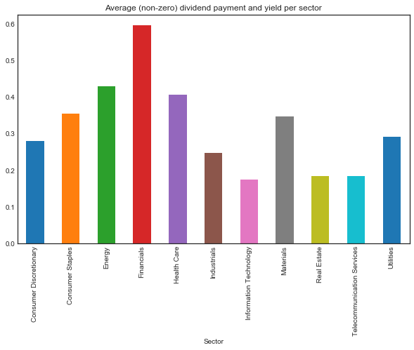

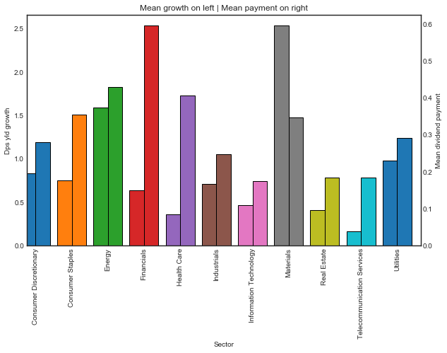

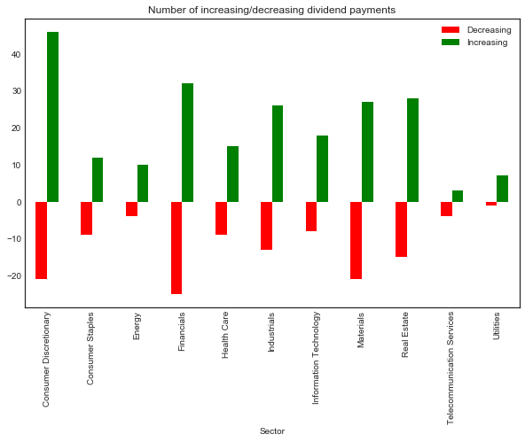

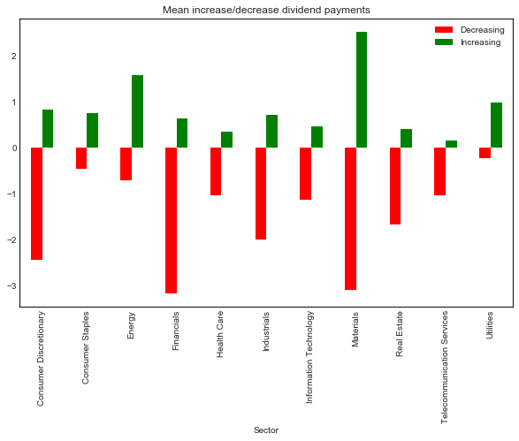

```python
display(
    'Mean past non zeo dividend payments'
    'Number of increasing/decreasing dividend payments',Sectors['Dps yld growth'].agg([('Decreasing' , lambda x : -x[x < 0].count()) ,
('Increasing' , lambda x : x[x > 0].count())]).fillna(0),

'Mean increase/decrease dividend payments',Sectors['Dps yld growth'].agg([('Decreasing' , lambda x : x[x < 0].mean()) ,
('Increasing' , lambda x : x[x > 0].mean())]).fillna(0)
     )
df[df['Divs']>0].groupby(['Sector'])['Divs'].mean().plot('bar',
figsize=(10, 6), title='Average (non-zero) dividend payment and yield per sector'); #Add second column for yld
plt.show()

fig = plt.figure() # Create matplotlib figure

ax = fig.add_subplot(111) # Create matplotlib axes
ax2 = ax.twinx() # Create another axes that shares the same x-axis as ax.

width = 0.4

df[df['Dps yld growth']>0].groupby(['Sector'])['Dps yld growth'].mean().plot(kind='bar', figsize=(10, 6), ax=ax,edgecolor = "k", width=width, position=1)
df[df['Divs']>0].groupby(['Sector'])['Divs'].mean().plot(kind='bar', figsize=(10, 6), ax=ax2,edgecolor = "k", width=width, position=0, title = "Mean growth on left | Mean payment on right")

ax.set_ylabel('Dps yld growth')
ax2.set_ylabel('Mean dividend payment')

plt.show()

Sectors['Dps yld growth'].agg([('Decreasing' , lambda x : -x[x < 0].count()) ,
('Increasing' , lambda x : x[x > 0].count())]).plot(kind='bar',figsize=(10, 6), title='Number of increasing/decreasing dividend payments', color=['r','g'])
plt.show()

Sectors['Dps yld growth'].agg([('Decreasing' , lambda x : x[x < 0].mean()) ,
('Increasing' , lambda x : x[x > 0].mean())]).plot(kind='bar',figsize=(10, 6), title='Mean increase/decrease dividend payments', color=['r','g'])
plt.show()
```

```python
display(df[df['Divs']>0].set_index(['Code','Closing Price'],inplace=False).groupby(['Sector'])['Dps yld growth'].nlargest(2),
df[df['Divs']>0].set_index(['Code','Closing Price'],inplace=False).groupby(['Sector'])['Divs'].nlargest(2))
```

```
Sector                      Code  Closing Price
Consumer Discretionary      FLT   43.07            3.51
                            WES   34.72            1.75
Consumer Staples            SHV   6.90             0.82
                            AVG   0.47             0.77
Energy                      SMR   1.17             4.67
                            VEA   2.38             2.02
Financials                  KSL   1.15             2.60
                            PAC   4.64             2.34
Health Care                 MVF   1.05             1.27
                            CAJ   0.25             0.90
Industrials                 AQZ   2.80             1.96
                            QAN   5.66             1.13
Information Technology      DTL   1.83             1.02
                            IRE   13.68            0.81
Materials                   FMG   8.13             5.98
                            BHP   39.40            4.34
Real Estate                 CWP   5.69             0.79
                            SCP   2.56             0.36
Telecommunication Services  SDA   3.87             0.32
                            TPM   6.93            -0.03
Utilities                   EPW   1.80             2.49
                            PEA   0.65             2.34
Name: Dps yld growth, dtype: float64
```

```
Sector                      Code  Closing Price
Consumer Discretionary      WES   34.72           2.23
                            FLT   43.07           1.67
Consumer Staples            BKL   84.97           3.05
                            WOW   31.29           1.03
Energy                      WPL   35.59           2.00
                            CTX   26.89           1.18
Financials                  MQG   132.77          5.25
                            CBA   72.40           4.31
Health Care                 COH   179.81          3.00
                            CSL   197.04          2.28
Industrials                 CIM   48.48           1.56
                            MMS   13.00           0.73
Information Technology      REA   77.69           1.09
                            CAR   13.22           0.44
Materials                   RIO   102.47          4.16
                            BHP   39.40           1.59
Real Estate                 LLC   12.84           0.69
                            DXS   12.77           0.48
Telecommunication Services  MAQ   20.08           0.50
                            TLS   3.33            0.22
Utilities                   AGL   21.98           1.17
                            APA   9.57            0.45
Name: Divs, dtype: float64
```

This shows two shares with the largest dps yld growth and past dividend payments per sector

Now lets look at dividends as percentages compared to the purchase price of the share

```python
df[df['Divs']>0].set_index(['Code','Closing Price','Divs'],inplace=False).groupby(['Sector'])['Dividend yld'].nlargest(2)
```

```
Sector                      Code  Closing Price  Divs
Consumer Discretionary      WPP   0.59           0.06   10.59
                            ENN   1.86           0.16    8.48
Consumer Staples            CCL   8.54           0.47    5.50
                            MTS   2.67           0.13    4.87
Energy                      WHC   4.22           0.40    9.48
                            YAL   3.54           0.26    7.43
Financials                  MOC   0.88           0.18   20.45
                            ECX   0.91           0.16   17.53
Health Care                 PGC   0.44           0.03    7.09
                            SIG   0.51           0.04    6.90
Industrials                 SRG   0.38           0.04   11.84
                            REX   1.46           0.12    8.22
Information Technology      DWS   1.01           0.10    9.85
                            DDR   4.33           0.20    4.67
Materials                   PPG   0.13           0.02   15.38
                            AWC   2.43           0.31   12.88
Real Estate                 AVJ   0.51           0.05    9.90
                            SRV   2.77           0.26    9.39
Telecommunication Services  TLS   3.33           0.22    6.62
                            MAQ   20.08          0.50    2.49
Utilities                   SKI   2.21           0.16    7.22
                            NEW   1.39           0.08    5.58
Name: Dividend yld, dtype: float64
```

As a note some of these shares have very high dividend ylds, this may be due to Divs being last dividend payment, so a share could have dropped significantly in price to have that high yld.

To check for just the highest yield shares, we will now also include FE yields

```python
df[df['Divs']>0][['Code','Sector','Divs','FE Dps Mean FY1 Roll','FE Val Div_Yld Mean FY1','Dividend yld']].nlargest(10, columns= ['FE Val Div_Yld Mean FY1','Dividend yld'])
```

|  | Code | Sector | Divs | FE Dps Mean FY1 Roll | FE Val Div_Yld Mean FY1 | Dividend yld |
| --- | --- | --- | --- | --- | --- | --- |
| 26 | WHC | Energy | 0.40 | 0.43 | 10.08 | 9.48 |
| 245 | MCP | Consumer Discretionary | 0.09 | 0.10 | 9.41 | 8.29 |
| 33 | AWC | Materials | 0.31 | 0.23 | 9.30 | 12.88 |
| 338 | KSL | Financials | 0.08 | 0.11 | 9.24 | 6.64 |
| 344 | MOC | Financials | 0.18 | 0.08 | 9.09 | 20.45 |
| 230 | ENN | Consumer Discretionary | 0.16 | 0.17 | 9.06 | 8.48 |
| 379 | DWS | Information Technology | 0.10 | 0.09 | 8.87 | 9.85 |
| 281 | WPP | Consumer Discretionary | 0.06 | 0.05 | 8.82 | 10.59 |
| 57 | FMG | Materials | 0.23 | 0.72 | 8.81 | 2.83 |
| 333 | GMA | Financials | 0.17 | 0.21 | 8.74 | 6.98 |

I will now limit the price to 10 to discount shares whose price has dropped significantly (very rough way to do this just to overemphasis some information). This should provide more companies that pay full franking dividends (again very rough)*

```python
df[(df['Divs']>0) & (df['Closing Price']>10)].set_index(['Code','Closing Price','Divs'],inplace=False).groupby(['Sector'])['Dividend yld'].nlargest(2)
```

```
Sector                      Code  Closing Price  Divs
Consumer Discretionary      WES   34.72          2.23   6.42
                            JBH   24.99          1.32   5.28
Consumer Staples            BKL   84.97          3.05   3.59
                            WOW   31.29          1.03   3.29
Energy                      WPL   35.59          2.00   5.62
                            CTX   26.89          1.18   4.39
Financials                  NAB   24.86          1.98   7.96
                            WBC   26.16          1.88   7.19
Health Care                 SHL   24.84          0.81   3.26
                            ANN   26.47          0.60   2.27
Industrials                 MMS   13.00          0.73   5.62
                            SST   16.50          0.69   4.17
Information Technology      CAR   13.22          0.44   3.34
                            IRE   13.68          0.36   2.66
Materials                   RIO   102.47         4.16   4.06
                            BHP   39.40          1.59   4.04
Real Estate                 LLC   12.84          0.69   5.38
                            DXS   12.77          0.48   3.74
Telecommunication Services  MAQ   20.08          0.50   2.49
Utilities                   AGL   21.98          1.17   5.32
Name: Dividend yld, dtype: float64
```

Just looking at these codes there are some I recognise here that I know will pay a full franking dividend such as NAB and WBC (in financials, both major banks) or WES (wesfarmers)

```python
df[['Code','Divs','FE Dps Mean FY1 Roll']].nlargest(10, columns=['Divs','FE Dps Mean FY1 Roll'])
```

|  | Code | Divs | FE Dps Mean FY1 Roll |
| --- | --- | --- | --- |
| 339 | MQG | 5.25 | 5.92 |
| 323 | CBA | 4.31 | 4.31 |
| 103 | RIO | 4.16 | 4.62 |
| 287 | BKL | 3.05 | 2.94 |
| 129 | COH | 3.00 | 3.23 |
| 355 | PPT | 2.75 | 2.43 |
| 130 | CSL | 2.28 | 2.67 |
| 269 | WES | 2.23 | 2.84 |
| 310 | ASX | 2.16 | 2.52 |
| 27 | WPL | 2.00 | 1.91 |

A generic way to find good growth shares are to compare dps growth (forward estimate of dividends minues current dividend) to Eps growth (FE minus current). This will theoretically show the companies that are expected to grow and be safe investments.

```python
display(df[['Code','Dps growth']].set_index(['Code'],
inplace=False).nlargest(20,columns=['Dps growth']),

df[['Code','Dps yld growth']].set_index(['Code'],
inplace=False).nlargest(20,columns=['Dps yld growth']),

df[['Code','Eps growth']].set_index(['Code'],
inplace=False).nlargest(20,columns=['Eps growth']),


pd.merge(df[['Code','Dps growth','Sector']].set_index(['Code'],
inplace=False).nlargest(20,columns=['Dps growth']),df[['Code','Eps growth','Sector','Closing Price']].set_index(['Code'],
inplace=False).nlargest(20,columns=['Eps growth']), on=['Code','Sector']),

'Grouped by Sector',
pd.merge(df[['Code','Dps growth','Sector']].set_index(['Code'],
inplace=False).nlargest(20,columns=['Dps growth']),df[['Code','Eps growth','Sector','Closing Price']].set_index(['Code'],
inplace=False).nlargest(20,columns=['Eps growth']), on=['Code','Sector']).groupby('Sector').size())
```

| Code | Dps growth |
| --- | --- |
| BHP | 1.71 |
| FLT | 1.51 |
| MQG | 0.67 |
| WES | 0.61 |
| CRN | 0.60 |
| FMG | 0.49 |
| RIO | 0.47 |
| CSL | 0.39 |
| MFG | 0.37 |
| ASX | 0.35 |
| COL | 0.32 |
| COH | 0.23 |
| ORG | 0.20 |
| JIN | 0.15 |
| REA | 0.14 |
| ALU | 0.13 |
| BXB | 0.13 |
| IRE | 0.11 |
| MYO | 0.11 |
| PAC | 0.11 |

| Code | Dps yld growth |
| --- | --- |
| CRN | 20.97 |
| BRL | 14.67 |
| JMS | 13.74 |
| RDC | 7.57 |
| VTH | 6.49 |
| FMG | 5.98 |
| SMR | 4.67 |
| BHP | 4.34 |
| CCX | 4.09 |
| PPE | 4.00 |
| GLL | 3.90 |
| OVH | 3.52 |
| FLT | 3.51 |
| AHY | 3.34 |
| MYO | 3.27 |
| ORG | 2.81 |
| KSL | 2.60 |
| COL | 2.58 |
| EPW | 2.49 |
| DCG | 2.35 |

| Code | Eps growth |
| --- | --- |
| SGH | 2.38 |
| BHP | 1.76 |
| PVS | 1.41 |
| ORI | 1.05 |
| RHC | 0.99 |
| MQG | 0.98 |
| CSL | 0.95 |
| ERA | 0.79 |
| NCM | 0.69 |
| COL | 0.66 |
| MFG | 0.65 |
| MYR | 0.63 |
| FMG | 0.63 |
| KAR | 0.62 |
| WES | 0.57 |
| REA | 0.54 |
| JHX | 0.53 |
| EPW | 0.48 |
| MMS | 0.48 |
| ALL | 0.48 |

| Code | Dps growth | Sector | Eps growth | Closing Price |
| --- | --- | --- | --- | --- |
| BHP | 1.71 | Materials | 1.76 | 39.40 |
| MQG | 0.67 | Financials | 0.98 | 132.77 |
| WES | 0.61 | Consumer Discretionary | 0.57 | 34.72 |
| FMG | 0.49 | Materials | 0.63 | 8.13 |
| CSL | 0.39 | Health Care | 0.95 | 197.04 |
| MFG | 0.37 | Financials | 0.65 | 40.65 |
| COL | 0.32 | Consumer Staples | 0.66 | 12.48 |
| REA | 0.14 | Information Technology | 0.54 | 77.69 |

```
'Grouped by Sector'
```

```
Sector
Consumer Discretionary        1
Consumer Staples              1
Energy                        0
Financials                    2
Health Care                   1
Industrials                   0
Information Technology        1
Materials                     2
Real Estate                   0
Telecommunication Services    0
Utilities                     0
dtype: int64
```

The above merged table is technically the best shares in the ALL ORDs with all of them being strong starting investments. There do not seem to be any major trends by sector from this as there is a normal looking spread. You will notice that there are no major banks on this list, despite banks being a strong defensive stock they are generally expected to keep current levels of performance (i.e. not grow exponentially) thus good shares to have when comparing growth factors they are not present.

# 5. Results/Insights

Discuss any non-trivial result or insight into the problem stemming from your analysis.

**Create as many code, markdown and raw cells as needed**

Below is a summary of results

### Insights gained About shares:

##### Attempting to realise a gain

- It is possible to identify plenty of shares under their sectors EV. These shares will either be undervalued or the companies are just poorly performing (qualitative analysis required)
- Linking EV to other values seems to give a random spread of shares (specifically linking to the P/E, though there was generally more gain than loss)
- There are many other factors that can be limited in these shares in an attempt to find only undervalued shares though it is still random

##### Growth and defensive shares

- These types of shares are easily identifiable
- Industry standard to find top shares are through dividend growth and eps growth. These shares could be called the top shares of the ALL ORDs
- Dividend yield can be much higher for smaller riskier companies
- Some larger companies will pay the taxes on their dividend payments and thus they will be tax free, thus unlike interest earnings or sale earnings will not be taxed.

# 6. In hindsight...

In this section you should reflect on your work and what you've learned. In particular you should include:

- a discussion of the most challenging aspect of the data analysis and if/how you overcame the challenge.
- a discussion of any programming technique and/or reference you found particularly useful or helpful for your project.
- an assessment of the outcome of the study in relation to the original goals (i.e., have the goals been reached, or did you have to reassess the goals during the project, and if so why?).
- a discussion of what new, or surprising knowledge or insight into the problem you've gained by conducting the study.
- a discussion of whether you would approach the problem differently if given an opportunity to redo the work, and any advice they would give to someone who would want to work on a similar problem.
- a discussion of how your analysis could be improved or extended in future work.

### Most challenging aspect of the data analysis and if/how you overcame the challenge

- The data was easy to work with being just numbers generally.
- The biggest challenged faced was knowing what all the data meant and how to use it to find what results I wanted, which I overcame by talking to industry professionals and doing self research.
- Another major challenge was the time constraint. I had to limit the amount of datasets I was using to just two. This was plenty to find useful insights into the ALL ORDs but there could have been far more to be gained by using multiple time based forward predictions of using the same set daily and comparing changes. Also there were other types of data that could have been included such as location of companies or shortsell information

### Programming technique and/or reference you found particularly useful or helpful for your project

- The pandas and plots were the main programming techniques used
- Groupby techniques were the most helpful as they allowed me to drill down on sector information
- Additionally merging was execptionally helpful inregards to finding shares that were tops of several different categories

### Outcome of the study in relation to the original goals

- We were able to determine several top shares for dividend growth or just to defensive savings. There were also some shares that could have been top picks to realise gain. However, these types of shares require plently of qualitive analysis.
- There was some insight gained into sectors, which would support future investment decisions

### How would I approach the project differently if given the opportunity to redo the work and what analysis could be improved or extended in future work

- If given the opportunity to redo this project I would have focused more on specific shares and used the same first dataset (df1) over several days in an attempt to do more statistical analysis and regression
- Given future data it would have been significantly easier to predict future stocks (when focusing on gains) however this would probably have had little impact on defensive/growth shares